# Data Driven Financials: Personal Portfolio FF5 Analysis

**By Ethan Kraus & Arzaan Singh**

GitHub Website: https://ethank47.github.io/  
GitHub Repository: https://github.com/ethank47/ethank47.github.io

## Project Goal

**Objectives:**

1. Estimate FF5 coefficients (alpha and β₁…β₅) for each portfolio.
2. Interpret those factor exposures and the resulting alpha.
3. Build predictive models to forecast future portfolio performance.
4. Compare historical and simulated returns to evaluate which portfolio is likely to outperform.

**Datasets:**

- Fama–French 5-Factor data from [Ken French’s Data Library](https://mba.tuck.dartmouth.edu/pages/faculty/ken.french/data_library.html)
- S&P 500 total return data from CapitalIQ
- Individual stock prices via the [Yahoo Finance API](https://pypi.org/project/yfinance/)

## Research Questions

This tutorial addresses two key questions:

## Project Outline

To answer our research questions, we proceed in three main stages:

1. **FF5 Factor Data**
   - **ETL:** Download and clean the daily Fama–French 5-factor CSV from Ken French’s site.
   - **EDA:** Explore factor distributions, pairwise correlations, and trends over time.
   - **Validation:** Align and compare the FF5 market factor (“Mkt-RF”) against SPY total-return data to ensure consistency.
2. **Portfolio Data & Construction**
   - **ETL:** Fetch historical adjusted-close prices via `yfinance`, set proper dtypes, and handle missing dates.
   - **Assembly:** Build dynamic, equal-weight portfolios for Arzaan and Ethan, automatically adjusting weights when new stocks IPO.
   - **EDA:** Compute and visualize portfolio return distributions, summary statistics, and correlation heatmaps.
3. **Modeling & Forecasting**
   - **Regression:** Run multi-linear FF5 regressions (α and βs) with K-Fold cross-validation on daily excess returns.
   - **Simulation:** Monte-Carlo sample the factors (plus idiosyncratic ε shocks and bootstrapped RF) to generate future return paths.
   - **Evaluation:** Summarize simulated outcomes (mean, variance, percentiles), plot mean trajectories, and draw insights on forecasted performance.

## Collaboration Plan

We’ll collaborate by meeting at least twice a week—either in person or virtually via FaceTime/Zoom—with day-to-day updates exchanged over iMessage. In Google Colab, each of us will own specific sections of the notebook to prevent merge conflicts, and we’ll periodically download the `.ipynb`, convert it to HTML, and push updates to our GitHub Pages site using VS Code and GitHub Desktop.

## Library Imports and Install

Library Imports Explained:

- **`from google.colab import drive` / `drive.mount()`**  
  Mounts your Google Drive into Colab so you can read/write files directly.
- **`import pandas as pd`**  
  Provides the DataFrame structure and powerful data manipulation tools.
- **`import numpy as np`**  
  Offers N-dimensional arrays and fast numerical operations.
- **`from datetime import date`**  
  Handles date objects to dynamically compute start/end dates for downloads.
- **`import yfinance as yf`**  
  Fetches historical market data (stock prices, dividends) from Yahoo Finance.
- **`from sklearn.linear_model import LinearRegression`**  
  Fits the Fama–French multi-linear regression models to estimate α and βs.
- **`from sklearn.model_selection import KFold`**  
  Splits the data into K sequential folds for cross-validation of the regression.
- **`import matplotlib.pyplot as plt`**  
  Core plotting functions for line charts, histograms, etc.
- **`from matplotlib.ticker import PercentFormatter`**  
  Formats axis tick labels as percentages (e.g., “25%”).
- **`import seaborn as sns`**  
  High-level interface for attractive statistical graphics (heatmaps, distributions).
- **`import warnings; warnings.filterwarnings('ignore')`**  
  Suppresses non-critical warnings to keep the notebook output clean.

```python
# Mount Google Drive for data access
from google.colab import drive
drive.mount('/content/drive')

# Core data libraries
import pandas as pd
import numpy as np
from datetime import date

# Data retrieval
!pip install --quiet yfinance
import yfinance as yf

# Modeling tools
from sklearn.linear_model import LinearRegression
from sklearn.model_selection import KFold
from sklearn.metrics import r2_score, mean_squared_error

# Visualization
import matplotlib.pyplot as plt
from matplotlib.ticker import PercentFormatter
import seaborn as sns

# Suppress non-critical warnings for cleaner output
import warnings
warnings.filterwarnings('ignore')

print('Imports Done :)')
```

```
Imports Done :)
```

## 1. Fama–French 5-Factor Data: ETL & Validation

In this section we will:

1. **Load** the daily Fama–French 5-factor CSV from Ken French’s Data Library.
2. **Clean & transform** the data:
   - Rename the date column
   - Parse dates into a `DatetimeIndex`
   - Convert all factor and risk-free values from percentages to decimals
3. **Validate** the dataset using the first factor as a bell-weather: Market Risk Premium `Mkt-RF + RF` against SPY’s observed daily simple returns to ensure our FF5 series aligns with total market returns.

### Fama–French 5-Factor Regression

We model each portfolio’s **daily excess return** (R_{p,t} - R_{f,t}) as:

$$ R_{p,t} - R_{f,t} = \alpha_p \;+\;\beta_{p,\mathrm{MKT}}\,( \mathrm{MKT}_t - R_{f,t} ) \;+\;\beta_{p,\mathrm{SMB}}\,\mathrm{SMB}_t \;+\;\beta_{p,\mathrm{HML}}\,\mathrm{HML}_t \;+\;\beta_{p,\mathrm{RMW}}\,\mathrm{RMW}_t \;+\;\beta_{p,\mathrm{CMA}}\,\mathrm{CMA}_t \;+\;\varepsilon_{p,t} $$

where

$$ \varepsilon_{p,t} \sim \mathcal{N}\bigl(0,\;\sigma_{\mathrm{resid}}^2\bigr) $$

and the five factors are:

- **MKT–RF (Market):** excess return of the broad market over the risk-free rate
- **SMB (Small Minus Big):** small-cap minus large-cap returns
- **HML (High Minus Low):** value (high book-to-market) minus growth returns
- **RMW (Robust Minus Weak):** high-profitability minus low-profitability returns
- **CMA (Conservative Minus Aggressive):** low-investment minus high-investment returns

### Data Extraction, Transform, and Load (ETL)

1. **Fama–French 5-Factor Data**
   - Read the CSV from Ken French’s library
   - Rename the date column and parse it as a `DatetimeIndex`
   - Convert all factor and risk-free values from percentages into decimal form
   - Inspect dtypes and handle any missing values
2. **S&P 500 Total Return Data**
   - Read the CapitalIQ export containing `Dates`, `Price`, and `Price Change`
   - Parse `Dates` into a `DatetimeIndex` and sort chronologically
   - Recompute or validate daily market returns as necessary
   - Align the resulting series with the FF5 dates for downstream analysis

After loading, we’ll display `.info()` and `.head()` for each to confirm they are tidy and ready for EDA.

Starting with the FF5 Factor Data

```python
# Read CSV without using the deprecated date_format argument
ff5_raw = pd.read_csv(
    "/content/drive/MyDrive/Colab Notebooks/F-F_Research_Data_5_Factors_2x3_daily.CSV",
    header=0,
    names=None
)

# Rename the first column to "Dates" and parse it explicitly
ff5_raw = ff5_raw.rename(columns={"Unnamed: 0": "Dates"})
ff5_raw["Dates"] = pd.to_datetime(ff5_raw["Dates"].astype(str), format="%Y%m%d")

# Set the Date column as the DataFrame index
ff5_df = ff5_raw.set_index("Dates").sort_index()

# Convert all factor and RF columns from percent to decimal
factor_cols = [c for c in ff5_df.columns if c not in ["RF"]] + ["RF"]
ff5_df[factor_cols] = ff5_df[factor_cols].astype(float).div(100.0)

# Inspect the resulting DataFrame
print("FF5 DataFrame shape and types:")
ff5_df.info()
print("\nFirst thre rows:")
display(ff5_df.head(3))
```

```
FF5 DataFrame shape and types:
<class 'pandas.core.frame.DataFrame'>
DatetimeIndex: 15481 entries, 1963-07-01 to 2024-12-31
Data columns (total 6 columns):
 #   Column  Non-Null Count  Dtype
---  ------  --------------  -----
 0   Mkt-RF  15481 non-null  float64
 1   SMB     15481 non-null  float64
 2   HML     15481 non-null  float64
 3   RMW     15481 non-null  float64
 4   CMA     15481 non-null  float64
 5   RF      15481 non-null  float64
dtypes: float64(6)
memory usage: 846.6 KB

First thre rows:
```

| Dates | Mkt-RF | SMB | HML | RMW | CMA | RF |
| --- | --- | --- | --- | --- | --- | --- |
| 1963-07-01 | -0.0067 | 0.0002 | -0.0035 | 0.0003 | 0.0013 | 0.00012 |
| 1963-07-02 | 0.0079 | -0.0028 | 0.0028 | -0.0008 | -0.0021 | 0.00012 |
| 1963-07-03 | 0.0063 | -0.0018 | -0.0010 | 0.0013 | -0.0025 | 0.00012 |

Luckily, there are no NaN values and we can continue by loading in our S&P 500 dataset

```python
# Read CSV and parse Dates column
sp500_df = pd.read_csv(
    '/content/drive/MyDrive/Colab Notebooks/S&P 500 Total Return.csv',
    parse_dates=['Dates']
)

# Rename the verbose price column
sp500_df = sp500_df.rename(columns={'S&P 500 Net (Total Return) Index (^SPXNTR) - Index Value': 'SPY_Price'})

# Set Dates as index and sort chronologically
sp500_df = sp500_df.set_index('Dates').sort_index()

# Compute daily simple returns (if not already provided) and fill any NaN's with 0 (namely first cell)
sp500_df['SPY_Daily_Return'] = sp500_df['SPY_Price'].pct_change().fillna(0)

# Inspect the cleaned DataFrame
print("S&P 500 Total Return Data:")
sp500_df.info()
display(sp500_df.head(3))
```

```
S&P 500 Total Return Data:
<class 'pandas.core.frame.DataFrame'>
DatetimeIndex: 3772 entries, 2010-03-18 to 2025-03-14
Data columns (total 2 columns):
 #   Column            Non-Null Count  Dtype
---  ------            --------------  -----
 0   SPY_Price         3772 non-null   float64
 1   SPY_Daily_Return  3772 non-null   float64
dtypes: float64(2)
memory usage: 88.4 KB
```

| Dates | SPY_Price | SPY_Daily_Return |
| --- | --- | --- |
| 2010-03-18 | 1816.80 | 0.000000 |
| 2010-03-19 | 1807.55 | -0.005091 |
| 2010-03-22 | 1816.79 | 0.005112 |

### Exploratory Data Analysis (EDA): S&P 500 Benchmark

Before we proceed, let us look at how our data looks. To do this, we explore the historical behavior of the S&P 500 Total Return index to understand the market backdrop and validate our factor data.

1. **Plot the Total Return Index** to visualize long-term growth and major market swings.
2. **Plot Daily Percentage Returns** to highlight volatility and the random-walk nature of market moves.
3. **Summarize Daily Return Statistics** (mean and standard deviation) to quantify the average drift and typical daily fluctuations.

To do this, we will primarily use line graphs/plots since we are using a time series:

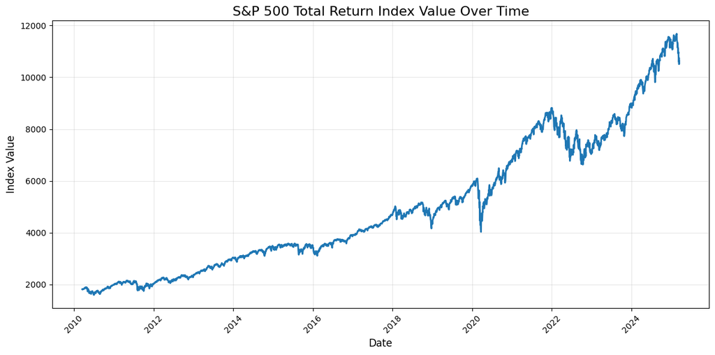

```python
plt.figure(figsize=(12, 6))
sns.lineplot(x=sp500_df.index, y='SPY_Price', data=sp500_df, lw=2)

plt.title('S&P 500 Total Return Index Value Over Time', fontsize=16)
plt.xlabel('Date', fontsize=12)
plt.ylabel('Index Value', fontsize=12)

plt.xticks(rotation=45)
plt.grid(alpha=0.3)
plt.tight_layout()
plt.show()
```

The plot below shows the day‐to‐day percentage changes in the S&P 500 Total Return index. The wild swings highlight the market’s volatility and underscore why a factor model (like FF5) can help explain systematic vs. purely random moves.

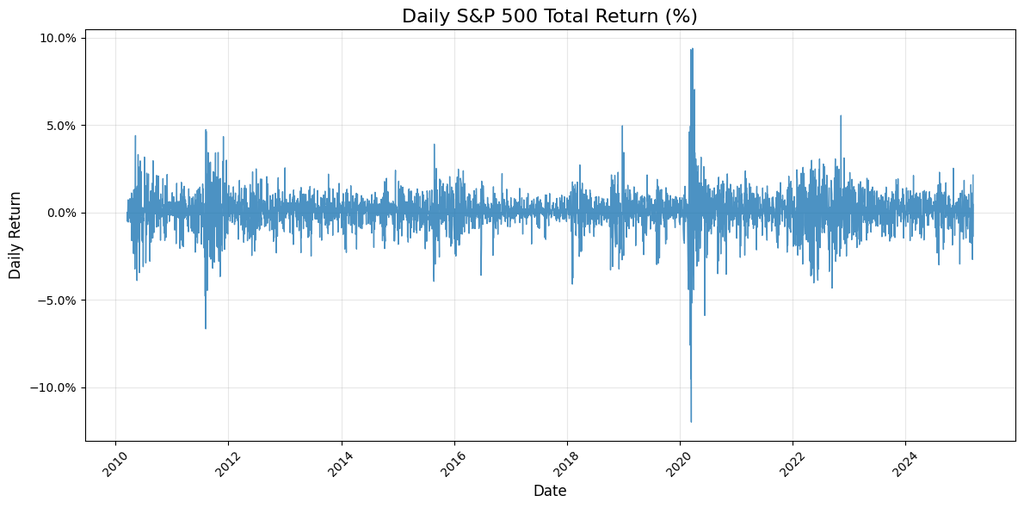

```python
plt.figure(figsize=(12, 6))
sns.lineplot(
    data=sp500_df,
    x=sp500_df.index,
    y='SPY_Daily_Return',
    lw=1,
    alpha=0.8
)

plt.title('Daily S&P 500 Total Return (%)', fontsize=16)
plt.xlabel('Date', fontsize=12)
plt.ylabel('Daily Return', fontsize=12)
plt.gca().yaxis.set_major_formatter(PercentFormatter(1.0))  # format as %
plt.xticks(rotation=45)
plt.grid(alpha=0.3)
plt.tight_layout()
plt.show()
```

Now that seems like an extremely noisy plot. That is why most Economists model stock price returns as a random walk. However, there is a drift (positive expected value) to this daily change, as shown below. This small drift gives it its distinictive exponential look and the variance explains why the market is considered so volatile (scary!).

To quantify the market’s overall drift and volatility, we compute:

- **Average Daily Return**: the mean of the daily price change.
- **Daily Volatility**: the standard deviation of daily price returns, reflecting typical daily swings.

```python
# Simple summary statistics that explain volatility versus the general trend above
# Std.dev explains why there is so much volatility
# Mean explains why the larger trend is still positive
# Compute and display daily return statistics
stats = sp500_df['SPY_Daily_Return'].agg(['mean', 'std']) \
               .rename({'mean':'Average Daily Return', 'std':'Daily Volatility'})

import pandas as pd
stats = stats.to_frame(name='Value').reset_index().rename(columns={'index':'Metric'})
stats['Value'] = stats['Value'].map("{:.2%}".format)
stats
```

|  | Metric | Value |
| --- | --- | --- |
| 0 | Average Daily Return | 0.05% |
| 1 | Daily Volatility | 1.09% |

### Validating FF5 Factors Against the S&P 500

Before using the Fama–French series in our models, we verify that it truly represents the broad market:

1. **Align Dates:** Restrict `ff5_df` and `sp500_df` to their overlapping trading days.
2. **Correlation Matrix:** Compute correlations among the five FF factors, the risk-free rate, and the S&P 500’s daily return.
3. **Key Checks:**
   - **Market Consistency:** `MKT–RF + RF` (total market return) should correlate very strongly (≈ 1.0) with `SPY_Daily_Return`.
   - **Factor Relationships:** Inspect off-diagonal entries to detect any unusually high inter-factor correlations that might signal multicollinearity.

```python
# Align FF5 & SPY on common trading dates
common_dates = ff5_df.index.intersection(sp500_df.index)
ff5_trimmed  = ff5_df.loc[common_dates]
spy_trimmed  = sp500_df.loc[common_dates]

# Build a single DataFrame for validation
valid_df = (
    ff5_trimmed[['Mkt-RF','SMB','HML','RMW','CMA','RF']]
    .assign(SPY_Daily_Return=spy_trimmed['SPY_Daily_Return'])
)

# Correlation matrix
corr_matrix = valid_df.corr()

# Check that MKT–RF + RF ≈ SPY
valid_df['MKT_Total'] = valid_df['Mkt-RF'] + valid_df['RF']
print("Corr(MKT_Total, SPY_Daily_Return) =",
      valid_df['MKT_Total'].corr(valid_df['SPY_Daily_Return']))
```

```
Corr(MKT_Total, SPY_Daily_Return) = 0.9958515860491032
```

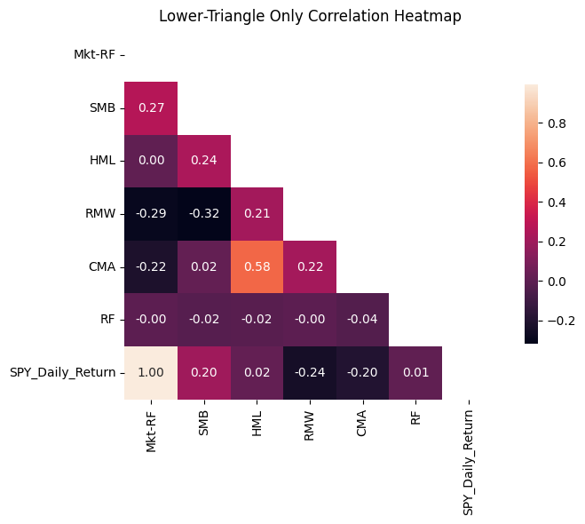

```python
# In general, we can look at the heatmap to get an overview of each variable
# Create a mask to only display values/heatmap below diagnol so it is easier to read
mask = np.triu(np.ones_like(corr_matrix, dtype=bool))

plt.figure(figsize=(8, 6))
sns.heatmap(
    corr_matrix,
    mask=mask,            # hide True values (the upper triangle)
    annot=True,
    fmt=".2f",
    square=True,
    cbar_kws={"shrink": .7}
)
plt.title("Lower‐Triangle Only Correlation Heatmap")
plt.tight_layout()
plt.show()
```

The correlation analysis confirms that the FF5 **market premium** (`MKT–RF + RF`) aligns almost perfectly with the actual S&P 500 daily return (correlation ≈ 0.99). This demonstrates that our FF5 series truly reflects broad market behavior.

These patterns match economic intuition and give us confidence that the FF5 dataset is valid for explaining and forecasting portfolio returns.

## 2. Portfolio Data & Construction

Now, in this stage we assemble and analyze two dynamic, equal-weight portfolios—one for Arzaan, one for Ethan—using live price data:

### Loading and Processing Raw Stock Price Returns

We define our portfolios, the start date and end date for our analysis. This is simple, since we already have our invested portfolio and the start and end data of our FF5 data.

Additionally, since we are using the Yahoo Finance API, the process of getting our data is also very simple.

```python
# Define portfolio as a dictionary of ticker symbols which we will use to extract data from yahoo finance API
portfolios = {
    "Arzaan": ["GOOGL", "T", "RIVN", "BA", "ARCC", "UBER", "INTC", "VTI", "ROKU", "CROX", "AMZN", "UPS", "TSLZ", "VGSH", "TSLA"],
    "Ethan":  ["LMT", "COST", "V", "NVDA", "WMT", "GOOGL", "AAPL", "MSFT"],
    "SPY": ["SPY"]
}

# Let us get start and end dates to pull the data from yahoo finance
# For now, let's just use a dummy date for ease
start_date = "2010-03-18"

# Get today's date in the correct format
end_date = date.today().isoformat()
print("Pulling data from", start_date, "to", end_date)

all_tickers = [t for lst in portfolios.values() for t in lst]
print(f"List of all tickers: {all_tickers}")
```

```
Pulling data from 2010-03-18 to 2025-04-27
List of all tickers: ['GOOGL', 'T', 'RIVN', 'BA', 'ARCC', 'UBER', 'INTC', 'VTI', 'ROKU', 'CROX', 'AMZN', 'UPS', 'TSLZ', 'VGSH', 'TSLA', 'LMT', 'COST', 'V', 'NVDA', 'WMT', 'GOOGL', 'AAPL', 'MSFT', 'SPY']
```

We have successfully defined our portfolios in a list and our start/end date. Now the more interesting part, getting the data from Yahoo Finance:

```python
# Now that we have all the tickers we want, let's get our Adjusted Close Prices for each
prices = yf.download(
    all_tickers,
    start=start_date,
    end=end_date,
    auto_adjust=True,   # returns only adjusted close price (this includes dividends, stock splits, etc)
    threads=False,
    progress=False
)
prices.head(2)
```

| Price Ticker Date | Close AAPL | Close AMZN | Close ARCC | Close BA | Close COST | Close CROX | Close GOOGL | Close INTC | Close LMT | Close MSFT | ... | Volume SPY | Volume T | Volume TSLA | Volume TSLZ | Volume UBER | Volume UPS | Volume V | Volume VGSH | Volume VTI | Volume WMT |
| --- | --- | --- | --- | --- | --- | --- | --- | --- | --- | --- | --- | --- | --- | --- | --- | --- | --- | --- | --- | --- | --- |
| 2010-03-18 | 6.760527 | 6.6380 | 3.355344 | 55.601555 | 43.794712 | 7.95 | 14.106731 | 14.489085 | 53.900570 | 22.351278 | ... | 196509100 | 22520710 | NaN | NaN | NaN | 7749200 | 18766000 | 6800 | 2714900 | 28416600 |
| 2010-03-19 | 6.688302 | 6.5175 | 3.268254 | 55.483864 | 43.401585 | 7.80 | 13.947333 | 14.352023 | 54.502678 | 22.336193 | ... | 226641100 | 47487511 | NaN | NaN | NaN | 7976500 | 24224000 | 1400 | 2010400 | 51552300 |

2 rows × 115 columns

We have all our price data. However, this is a bit overwhelming. We only want our Close prices, so that we can compare our Daily Price Return with FF5 model. Since, this is a multilevel DF, let's extract only our Close prices for each ticker symbol.

```python
# Grab only the Close columns (level 0 = “Close”)
adj_close = prices.xs("Close", axis=1, level=0).copy()

# Confirm this by displaying table.
print("Adjusted‑close DataFrame shape:", adj_close.shape)
print("Tickers:", adj_close.columns.tolist()[:5], "…")
display(adj_close.head(2))
```

```
Adjusted‑close DataFrame shape: (3801, 23)
Tickers: ['AAPL', 'AMZN', 'ARCC', 'BA', 'COST'] …
```

| Ticker Date | AAPL | AMZN | ARCC | BA | COST | CROX | GOOGL | INTC | LMT | MSFT | ... | SPY | T | TSLA | TSLZ | UBER | UPS | V | VGSH | VTI | WMT |
| --- | --- | --- | --- | --- | --- | --- | --- | --- | --- | --- | --- | --- | --- | --- | --- | --- | --- | --- | --- | --- | --- |
| 2010-03-18 | 6.760527 | 6.6380 | 3.355344 | 55.601555 | 43.794712 | 7.95 | 14.106731 | 14.489085 | 53.900570 | 22.351278 | ... | 88.576180 | 6.477575 | NaN | NaN | NaN | 39.966805 | 20.228273 | 48.455425 | 45.366753 | 13.535915 |
| 2010-03-19 | 6.688302 | 6.5175 | 3.268254 | 55.483864 | 43.401585 | 7.80 | 13.947333 | 14.352023 | 54.502678 | 22.336193 | ... | 88.127853 | 6.522317 | NaN | NaN | NaN | 39.910976 | 19.938759 | 48.407040 | 45.070072 | 13.390730 |

2 rows × 23 columns

That is a lot of useful data. But it is important to note, the first few rows have a lot of NaN's. This is because a lot of the companies in our portfolios did not exist or were not publicly traded in the 2010s. We will have to adjust this going forward. However, before that let us check that all our tickers actually got downloaded and that none of them only have NaNs:

```python
# Which tickers didn’t even make it into the columns?
missing_cols = [t for t in all_tickers if t not in adj_close.columns]

# Which tickers came through but have no data at all?
nan_only = [t for t in adj_close.columns if adj_close[t].isna().all()]

print("Never downloaded:", missing_cols)
print("Downloaded but all NaN:", nan_only)

# Our truly valid tickers:
valid_tickers = [t for t in prices.columns if t not in nan_only]
print("Valid tickers:", valid_tickers)
```

```
Never downloaded: []
Downloaded but all NaN: []
Valid tickers: [('Close', 'AAPL'), ('Close', 'AMZN'), ('Close', 'ARCC'), ('Close', 'BA'), ('Close', 'COST'), ('Close', 'CROX'), ('Close', 'GOOGL'), ('Close', 'INTC'), ('Close', 'LMT'), ('Close', 'MSFT'), ('Close', 'NVDA'), ('Close', 'RIVN'), ('Close', 'ROKU'), ('Close', 'SPY'), ('Close', 'T'), ('Clo…
```

Luckily, all our tickers are downloaded. This means that we can continue with portfolio construction.

#### Portfolio Construction and Statistics

Using the adj_close DF, we can compute our daily price returns using a simple function pct_change(). We could also fill NaNs with 0 simply because if there were no returns for the day or the stock did not yet exist, it means we could not have it in our portfolio. However, that would impact our regression and analysis, as it would essentially make that part of the portfolio stagnant until the stock goes public.

Rather, let's deal with it more realistically. Where we only include it in our equal weighted portfolio if it's value is not NaN -- i.e., the stock is public. The portfolio automatically adjusts its weights when the stock is made public and we purchase it.

```python
# We create a series (DF) with the price changes
daily_rets = adj_close.pct_change()

# Then create an empty DF of our portfolio with daily returns only on tickers in our respective portfolio and if the stock is public
port_dynamic = pd.DataFrame(index=daily_rets.index)

# For each item in the portfolio
for owner, tickers in portfolios.items():
    # Broadcasting: take the row‑wise mean, skipping NaNs automatically and constructing our portfolio only using available stock
    # This allows us to dynamically adjust the portfolio and weights to an equally weighted portfolio when a stock goes public
    port_dynamic[owner] = daily_rets[tickers].mean(axis=1, skipna=True)

# Cleaning if need be
port_dynamic.fillna(0, inplace=True)

# We now have one column per owner, where each day’s return is the average of only the available stocks that day.
print("Sample dynamic‑weight daily returns:")
display(port_dynamic.head())
```

```
Sample dynamic‑weight daily returns:
```

| Date | Arzaan | Ethan | SPY |
| --- | --- | --- | --- |
| 2010-03-18 | 0.000000 | 0.000000 | 0.000000 |
| 2010-03-19 | -0.008788 | -0.007191 | -0.005061 |
| 2010-03-22 | 0.008287 | 0.002732 | 0.005346 |
| 2010-03-23 | 0.012720 | 0.003892 | 0.007033 |
| 2010-03-24 | -0.006095 | -0.007854 | -0.004855 |

Let's use this to find cumulative returns before we dive into our analysis just to see what we are working with. To do this, we will use continously compounded returns that uses the log to compound returns.

```python
log_rets = np.log1p(port_dynamic)                            # Daily log-returns
cc_cum   = np.exp(log_rets.cumsum()) - 1                     # Continously compounded cumulative returns
yrs      = len(log_rets) / 252                               # Years in sample

# Now let's use those to create some summary statistics
summary_cc = pd.DataFrame({
    "Cum. Return": cc_cum.iloc[-1],
    "Log Return": log_rets.sum()    / yrs,
    "Simple Return": np.expm1(log_rets.sum() / yrs),
    "Volatility": log_rets.std() * np.sqrt(252)
})

print("\nSummary stats:")
display(summary_cc.style.format("{:.2%}"))
```

```
Summary stats:
```

|  | Cum. Return | Log Return | Simple Return | Volatility |
| --- | --- | --- | --- | --- |
| Arzaan | 1061.24% | 16.26% | 17.65% | 20.70% |
| Ethan | 2795.85% | 22.32% | 25.00% | 19.03% |
| SPY | 521.66% | 12.11% | 12.88% | 17.48% |

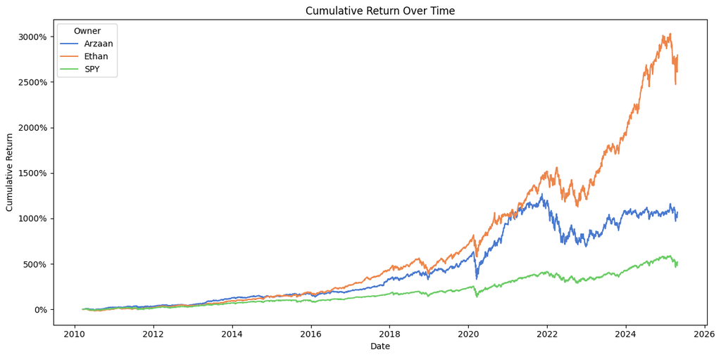

```python
# Pivot the cumulative-return DataFrame from wide to long format:
#  - reset_index() makes 'Date' a column instead of the index
#  - melt() gathers each Owner’s column into a single 'Cumulative Return' column
cc_long = cc_cum.reset_index().melt(
    id_vars="Date",           # keep 'Date' as identifier
    var_name="Owner",         # name for the new column that holds former column names
    value_name="Cumulative Return"  # name for the new column with return values
)

# Create a new figure with a defined size
plt.figure(figsize=(12, 6))

# Draw a line plot of cumulative returns over time for each Owner
sns.lineplot(
    data=cc_long,
    x="Date",                  # x-axis: dates
    y="Cumulative Return",     # y-axis: cumulative returns
    hue="Owner",               # color lines by Owner
    palette="muted"            # use a muted color palette
)

# Add a title and y-axis label
plt.title("Cumulative Return Over Time")
plt.ylabel("Cumulative Return")

# Format y-axis tick labels as percentages (e.g., 0.25 → 25%)
plt.gca().yaxis.set_major_formatter(
    plt.FuncFormatter(lambda v, _: f"{v:.0%}")
)

# Tighten layout to reduce whitespace
plt.tight_layout()

# Render the plot
plt.show()
```

As we can see, Ethan's portfolio has signficantly outperformed Arzaan's. Important to note, we both did outperform the SPY, so win for us. While this graph is interesting on its own (showing the magnitude of difference in returns) from picking different stocks, it will be even more interesting to find out why.

But one more thing. Diversification is an imperative concept in Finance - it is essentially the closest thing to a free lunch. Before we start predicting coefficients of risk and returns, we can have an initial crack at explaining why one portfolio might outperform another and understand systemtic vs idiosyncratic risk. So, let's look at correlation heatmaps between our portfolio's stocks and a measure of diversification.

The cell below cell computes each portfolio’s average pairwise correlation among its stocks and defines a diversification benefit as `1 - average correlation`, which quantifies the overall risk reduction from holding multiple assets.

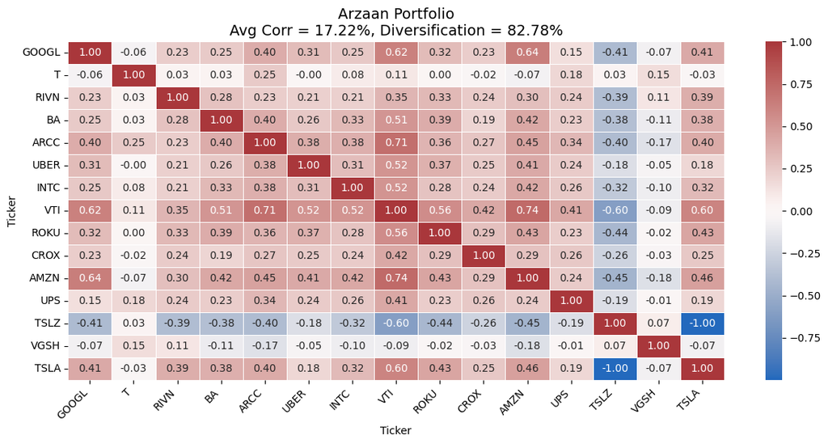

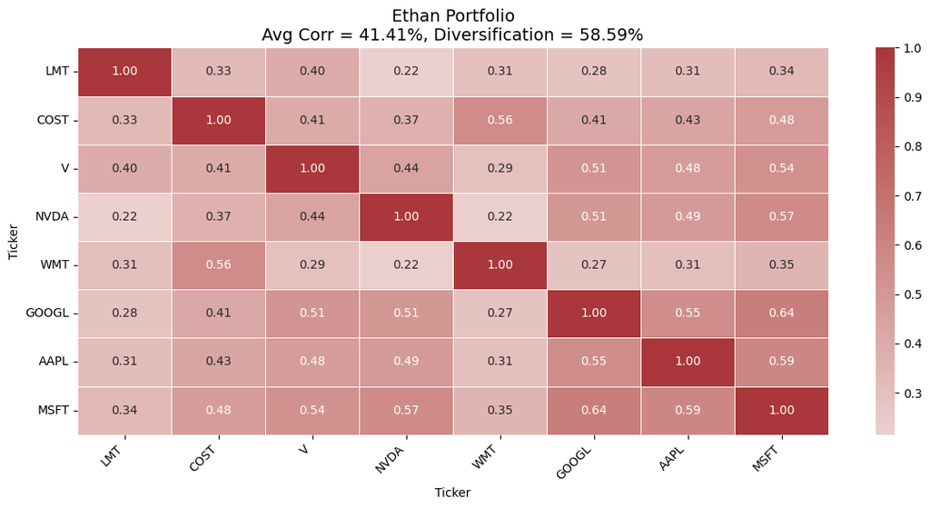

```python
# Combined correlation heatmap + diversification metric in one plot per portfolio
for owner, tickers in portfolios.items():
    if owner == "SPY":  # skip benchmark
        continue

    # 1) Compute daily returns and correlation matrix
    returns = adj_close[tickers].pct_change().dropna()
    corr = returns.corr()

    # 2) Calculate average pairwise correlation (off-diagonal)
    n = corr.shape[0]
    mask_offdiag = ~np.eye(n, dtype=bool)
    avg_corr = corr.values[mask_offdiag].mean()
    div_benefit = 1 - avg_corr

    # 3) Plot heatmap with metrics in the title
    plt.figure(figsize=(12, 6))
    sns.heatmap(
        corr,
        annot=True,
        fmt=".2f",
        cmap="vlag",
        center=0,
        linewidths=0.5
    )
    plt.title(
        f"{owner} Portfolio\n"
        f"Avg Corr = {avg_corr:.2%}, Diversification = {div_benefit:.2%}",
        fontsize=14
    )
    plt.xticks(rotation=45, ha="right")
    plt.yticks(rotation=0)
    plt.tight_layout()
    plt.show()
```

Suddenly, Ethan's outperformance makes a bit more sense. He is very concentrated into technology stocks which have historically outperformed the market by a lot. One other intersting observation to note: Arzaan's portfolio contains two perfectly negatively correlated stocks - TSLA and TSLZ. This is not naturally possible and was artifically created by using a short ETF for Tesla stock to hedge returns by Arzaan. Anyway, we must continue what we came here to do... see who will win in the future

## 3. Modeling & Forecasting

Finally, in this stage we will estimate factor exposures, quantify model fit, and generate forward‐looking forecasts:

1. **Regression:** Align daily excess returns with FF5 factors and fit multi‐linear models via K-Fold CV to estimate each portfolio’s α and β.
2. **Validation:** Report average R² and RMSE across folds (and optionally test on a hold-out period).
3. **Monte Carlo:** Simulate future factor paths (MV-Normal), add idiosyncratic $εₜ$ ~ $N(0,σ_r²)$ and bootstrapped RF, then compute daily returns $r_t = α + β·F_t + RF_t + εₜ$. Visualize and evaluate our results.

```python
# Defining a list of factors we will regress on
factor_list = ['Mkt-RF', 'SMB', 'HML', 'RMW', 'CMA']  # 5 factors
#factor_list = ['Mkt-RF', 'SMB', 'HML']  # 3 factors
#factor_list = ['Mkt-RF']  # 1 factors
```

### Regression and Feature Coefficients

```python
# Ensure datetime indices already set on ff5_df and port_dynamic
owners  = list(portfolios.keys())
factors = list(factor_list)

# Align dates of portfolio and ff5
common = ff5_df.index.intersection(port_dynamic.index)
ff5_slice  = ff5_df.loc[common, factors + ['RF']]
port_slice = port_dynamic.loc[common, owners]

# Build regression table
data = ff5_slice.join(port_slice).dropna()
X = data[factors].values
Y = data[owners].subtract(data['RF'], axis=0).values   # excess returns

# K-Fold with contiguous folds (no shuffling)
n_splits = max(2, min(5, len(data)))
kf = KFold(n_splits=n_splits, shuffle=False)

results = {o: {'alphas':[], 'betas':[]} for o in owners}

# Getting results for each K-fold for each alphas and betas
for train_idx, _ in kf.split(X):
    Xtr, Ytr = X[train_idx], Y[train_idx]
    for i, o in enumerate(owners):
        mdl = LinearRegression().fit(Xtr, Ytr[:, i])
        results[o]['alphas'].append(mdl.intercept_)
        results[o]['betas'].append(mdl.coef_)

# Getting our Average across folds
rows = []
for o in owners:
    rows.append([o,
                 np.mean(results[o]['alphas']),
                 *np.mean(results[o]['betas'], axis=0)])

beta_cols = [f"Beta_{f}" for f in factors]
ff5_summary = pd.DataFrame(rows,
                           columns=['Owner','Alpha'] + beta_cols
                          ).set_index('Owner')

display(ff5_summary.style.format("{:.4f}"))


# Add errors (MSE, MAE) and R^2 to evaluate model
# Add adjusted R^2 to evaluate the new features
```

| Owner | Alpha | Beta_Mkt-RF | Beta_SMB | Beta_HML | Beta_RMW | Beta_CMA |
| --- | --- | --- | --- | --- | --- | --- |
| Arzaan | 0.0002 | 0.9388 | 0.1877 | -0.0811 | -0.0928 | -0.3930 |
| Ethan | 0.0004 | 1.0047 | -0.1908 | -0.2670 | 0.2683 | -0.0743 |
| SPY | -0.0000 | 0.9841 | -0.1113 | 0.0215 | 0.0577 | 0.0349 |

The results above are truly astonishing (in the best way possible). Both Arzaan and Ethan outperformed the market by a lot:

- **Alpha (α):** the average daily excess return **not** explained by the five factors - the holy grail of finance.
  - Arzaan’s α ≈ 0.0002 → ~5 % p.a.
  - Ethan’s α ≈ 0.0004 → ~10 % p.a.
  - SPY’s α ≈ 0.

**Cross-referenced with realized performance (2010–2025):**

[output not shown]

Together, these factor coefficients and α explain why Ethan’s portfolio delivered far higher risk-adjusted returns than Arzaan’s over the same period.

### Validation: Cross‐Validated R² & RMSE

Now, let's see how well FF5 Factor data explains daily excess returns for our portfolios. Using the same K-Fold splits, we will:

- **Compute R²** on each test fold to measure explained variance.
- **Compute RMSE** on each test fold to gauge average prediction error (in daily return units).
- **Average** R² and RMSE across all folds for each portfolio to summarize model performance.

```python
# Prepare storage for R² and RMSE across folds
r2_scores   = {o: [] for o in owners}
rmse_scores = {o: [] for o in owners}

# Loop over folds
for train_idx, test_idx in kf.split(X):
    X_train, X_test = X[train_idx], X[test_idx]
    Y_train, Y_test = Y[train_idx], Y[test_idx]

    # Fit & evaluate per portfolio
    for i, owner in enumerate(owners):
        model = LinearRegression().fit(X_train, Y_train[:, i])
        y_pred = model.predict(X_test)

        # Record metrics
        r2_scores[owner].append(r2_score(Y_test[:, i], y_pred))
        rmse_scores[owner].append(
            np.sqrt(mean_squared_error(Y_test[:, i], y_pred))
        )

# Build summary table
cv_summary = pd.DataFrame({
    'Avg R2':   {o: np.mean(r2_scores[o])   for o in owners},
    'Avg RMSE': {o: np.mean(rmse_scores[o]) for o in owners}
}).T

# Display with formatting
cv_summary.style.format({
    'Avg R2': '{:.2%}',
    'Avg RMSE': '{:.4f}'
})
```

|  | Arzaan | Ethan | SPY |
| --- | --- | --- | --- |
| Avg R2 | 0.763969 | 0.845697 | 0.995154 |
| Avg RMSE | 0.005993 | 0.004345 | 0.000732 |

- **R² (explained variance)**
  - **SPY (0.995):** Virtually all of SPY’s daily excess‐return variation is captured by the FF5 factors—no surprise, since SPY *is* the market index.
  - **Ethan (0.846):** About 84.6 % of the day-to-day swings in Ethan’s excess returns are explained by the five factors. The remaining ~15 % is idiosyncratic (stock-specific) noise.
  - **Arzaan (0.764):** Roughly 76.4 % of Arzaan’s excess-return variability is explained by the factors; ~24 % remains unexplained, indicating a larger idiosyncratic component.
- **RMSE (root-mean-square error)**
  - **SPY (0.00073):** The model’s typical daily prediction error is just 0.07 %—essentially negligible for a broad index.
  - **Ethan (0.00435):** On average the model’s daily forecast for Ethan’s excess return errs by ~0.44 percentage points.
  - **Arzaan (0.00599):** The average daily error is ~0.60 percentage points, reflecting somewhat noisier, less‐well-captured returns.

**Take‐away:**  
The FF5 model fits **Ethan’s portfolio** better than **Arzaan’s**—consistent with Ethan’s higher R² and lower RMSE—because Ethan’s factor exposures (e.g. strong market, profitability, and growth tilts) more closely align with the systematic drivers captured by FF5. Arzaan’s holdings exhibit more idiosyncratic variation (smaller R², higher RMSE), suggesting higher stock‐specific risk or missing factors that the standard FF5 set does not capture. But both are high enough to show that the dataset is valid but also not perfect suggesting that there is *alpha* to be had.

On a personal note, seeing SPY’s near-perfect R² (0.995) drove home how well FF5 captures pure market risk—and why any residual α really must be true stock-picking skill. And, Ethan’s tiny tilt toward profitability (RMW) added up to a 2 % annual boost—a small change in β that yielded a large cumulative effect.

### Monte Carlo Simulation & Forecasting

With all our data, it comes down to this. We will use monte-carlo simulations to predict future performance using:

- **Residual volatility**: Estimate each portfolio’s idiosyncratic σₑ from the regression residuals:
  $$ \sigma_{\text{resid},p} = \mathrm{std}\bigl(R_{p,t} - R_{f,t} - (\alpha_p + \beta_p·F_t)\bigr). $$
- **Simulation setup**: **n_sims** = 10 simulated paths, **n_days** = 252 trading days (1 year), **rng** = reproducible random generator
- **Factor paths**: $F_{s,t}\sim\mathcal N(\mu_F,\Sigma_F)$ for each simulation $s$ and day $t$, where $\mu_F$ and $\Sigma_F$ are the historical FF5 factor mean and covariance.
- **Risk-free bootstrap**: Sample daily RFₜ from the empirical FF5 RF distribution to preserve its historical shape.
- **Idiosyncratic shocks**: For each owner $p$, $varepsilon_{s,t,p}\sim\mathcal N(0,\sigma_{\text{resid},p}^2)$; note: beta and factors are vectors.
- **Total return** for each sim (s), day (t), owner (p):
  $$ r_{s,t,p} = \alpha_p + \boldsymbol\beta_p \cdot \mathbf F_{s,t} + \mathrm{RF}_{s,t} + \varepsilon_{s,t,p}. $$
- **Cumulative simple returns**:
  $$ R_{s,t,p}^{\mathrm{cum}} = \prod_{u=1}^t (1 + r_{s,u,p}) - 1$$

```python
# Before we jump into the monte-carlo simulation we also want to use idiosyncractic risk of our portfolios in our preditiction
X_mat = data[factors].values
ones  = np.ones((len(data), 1))

# So, let's just find the residual erros
resid_std = {}
for owner in owners:
    alpha  = ff5_summary.loc[owner, 'Alpha']
    betas  = ff5_summary.loc[owner, [f'Beta_{f}' for f in factors]].values

    y_hat  = alpha + X_mat @ betas          # predicted excess return
    resid  = data[owner] - data['RF'] - y_hat
    resid_std[owner] = resid.std(ddof=1)    # σ_resid
```

```python
# simulation settings
n_sims, n_days = 10, 252
rng = np.random.default_rng(2)

owners = ff5_summary.index.tolist()
factors = factor_list

# empirical factor stats
F = ff5_df[factors]
mu_F, cov_F = F.mean().values, F.cov().values

# simulate factor paths
sim_F = rng.multivariate_normal(mu_F, cov_F, size=(n_sims, n_days))

# draw daily RF from history (vector of shape (sims, days))
rf_hist = ff5_df['RF'].values
sim_rf  = rng.choice(rf_hist, size=(n_sims, n_days))

# α and β
alpha_vec = ff5_summary['Alpha'].values                    # (owners,)
beta_mat  = ff5_summary[[f'Beta_{f}' for f in factors]].values  # (owners, factors)


# excess → total return: r = α + β·F + RF + ε
excess = np.einsum('sdf,of->sdo', sim_F, beta_mat)          # β·F

# build idiosyncratic shocks for each owner
eps = np.zeros_like(excess)
for i, owner in enumerate(owners):
    eps[:, :, i] = rng.normal(0, resid_std[owner], size=(n_sims, n_days))

total = excess + alpha_vec[None,None,:] + sim_rf[:,:,None] + eps
# cumulative simple returns, did this to be different from before for output. for a single year it is not that big of a deal
# however, for consistency sake if we had used continious returns before (we had not), then we would have used log returns here
cum = np.cumprod(1 + total, axis=1) - 1
sim_paths = {owners[i]: cum[:,:,i] for i in range(len(owners))}

# year-end summary (already 1-yr cumulative)
year_end = pd.DataFrame({o: p[:,-1] for o, p in sim_paths.items()})
summary  = pd.DataFrame({
    "Mean (1-yr)": year_end.mean(),
    "Var  (1-yr)": year_end.var(ddof=1),
    "5%":  year_end.quantile(0.05),
    "50%": year_end.quantile(0.50),
    "95%": year_end.quantile(0.95)
}).T
display(summary.style.format("{:.2%}"))
```

|  | Arzaan | Ethan | SPY |
| --- | --- | --- | --- |
| Mean (1-yr) | 14.50% | 9.83% | 6.38% |
| Var (1-yr) | 4.15% | 2.83% | 2.88% |
| 5% | -7.55% | -14.09% | -14.03% |
| 50% | 14.33% | 12.00% | 3.91% |
| 95% | 46.94% | 32.90% | 32.31% |

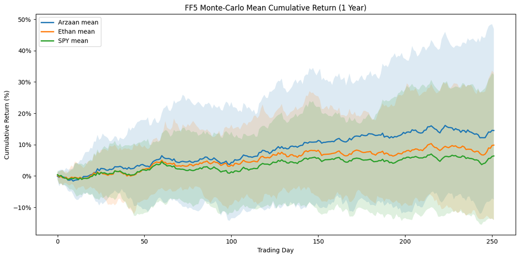

```python
# plot mean path (+ 90 % band for context)
plt.figure(figsize=(12,6))
x = np.arange(n_days)
for o, p in sim_paths.items():
    mean = p.mean(axis=0)
    low  = np.percentile(p, 5, axis=0)
    high = np.percentile(p, 95, axis=0)
    plt.plot(x, mean*100, lw=2, label=f"{o} mean")
    plt.fill_between(x, low*100, high*100, alpha=0.15)
plt.title("FF5 Monte-Carlo Mean Cumulative Return (1 Year)")
plt.xlabel("Trading Day"); plt.ylabel("Cumulative Return (%)")
plt.gca().yaxis.set_major_formatter(PercentFormatter())
plt.legend(); plt.tight_layout(); plt.show()
```

In the specific case above (we could always change the rng and get different results)

However, our biggest takeaway from this entire exercise is that it is almost impossible to predict the short-term performance of stocks. We tinkered with every metric, and yet the model changed in unexpected ways. Randomness was the biggest driver of any sustainable result and that is why we believed that monte-carlo simulations were the best simulation tool to accompany our linear regression.

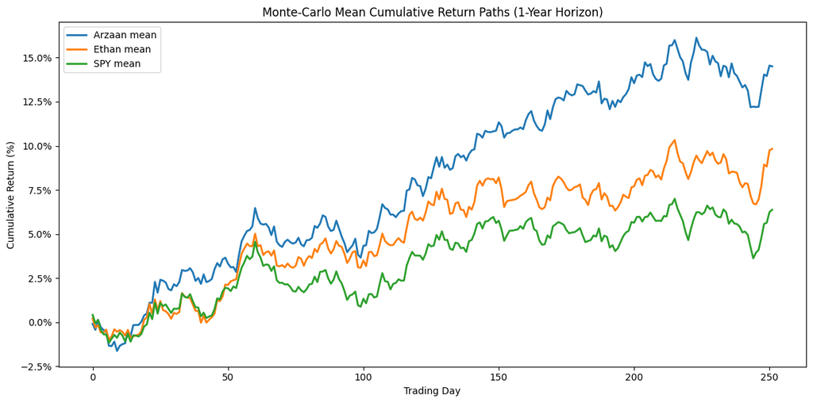

```python
# Plot only the mean Monte-Carlo path for each portfolio for any easier comparison

plt.figure(figsize=(12, 6))
x = np.arange(n_days)

for owner, paths in sim_paths.items():
    mean_path = paths.mean(axis=0) * 100
    plt.plot(x, mean_path, lw=2, label=f"{owner} mean")

plt.title("Monte-Carlo Mean Cumulative Return Paths (1-Year Horizon)")
plt.xlabel("Trading Day")
plt.ylabel("Cumulative Return (%)")
plt.gca().yaxis.set_major_formatter(PercentFormatter())
plt.legend()
plt.tight_layout()
plt.show()
```

## Conclusion & Next Steps

**Conclusions**

**Next Steps & Extensions**

1. **Out‐of‐Sample Testing:** Hold out the most recent quarter or year to assess true predictive power on unseen data.
2. **Alternate Factor Models:** Incorporate momentum or liquidity factors to see if they explain any residual variation (especially for Arzaan’s portfolio).
3. **GARCH‐Enhanced Simulation:** Replace the MV‐Normal assumption with GARCH‐based volatility forecasts to capture volatility clustering and fat tails.
4. **Dynamic Allocation Rules:** Explore factor‐tilted or risk‐parity weighting schemes instead of static equal weight.
5. **Transaction Costs & Practical Constraints:** Model the impact of rebalancing costs, slippage, and position limits to gauge real‐world implementability.

By combining academic factor models, robust cross‐validation, and forward‐looking simulation, this tutorial illustrates a comprehensive end-to-end data science workflow—and yields actionable insights into portfolio construction and forecasting.

## Further Resources

To dive deeper, here are few resources

- **Fama & French (2015)**: *A five-factor asset pricing model*, Journal of Financial Economics.  
  https://papers.ssrn.com/sol3/papers.cfm?abstract_id=2287202
- **Investopedia: Factor Investing**  
  https://www.investopedia.com/terms/f/factor-investing.asp
- **GARCH Modeling in Python** (arch package tutorial)  
  https://arch.readthedocs.io/en/latest/univariate/introduction.html
- **Towards Data Science: Monte Carlo in Finance**  
  https://towardsdatascience.com/monte-carlo-method-explained-8635edf2cf58/

```python
%%shell
```